# [Animal Movement and Spatial Ecology Lab](https://eligurarie.github.io/)

Values, Commitments, and Practicalities

Elie Gurarie

updated: 2026-08-25

*SUNY-ESF*

> *This is a living document. Any suggestions*  
> *for additions or revisions are welcome.*

## 1. Our Vision

At the [**Animal Movement and Spatial Ecology Lab (AMSEL)**](https://eligurarie.github.io/) we work on fundamental questions of how animals navigate, survive, and persist in complex and dynamic environments. Our approach straddles theory, methodological innovation, the deep exploration of empirical data, and a diversity of knowledge modes with an eye on human-wildlife interactions, conservation, and stewardship

What we do is summarized by the following equation:

$${\cal W} = \rho_1 {\cal N} + \rho_2
{\cal X} + \rho_3 {\cal M} + \rho_4 {\cal P} + \rho_5 {\cal A} +
...$$

Where:

- $\cal W$ is **who we are** and **what we do**
- $\cal N$ is the **natural world** - with all its complex of characters and interactions - which is our mission to explore
- $\cal X$ represents **data** and all the fascinating ways to expore it/them,
- $\cal M$ is **mathematical reasoning** which is powerful and cool,
- $\cal P$ is **people and communities** - whose interaction and coexistence with the natural world we aim to enrich and facilitate,
- $\cal A$ is **storytelling** and **visual communication**,
- $...$ is everything else that makes us and motivates us.

While each of us weights these in our own way in different ways, for all of us these coefficients are positive ($\rho_i \gg 0$), and the sum of them is something very large and very satisfying ($\sum \rho_i \gg 1$).

## 2. Core Values

We are all **colleagues**, Whether you’re an undergraduate intern or a seasoned postdoc, your contributions matter. Everyone brings their own perspectives, knowledge and ideas. There are many projects underway at any moment, but the tools and approaches and philosophies we bring overlap tremendously, and we all help each other and inspire each other. What we accomplish collectively is so, so, so much more than individually.

Our work is **collaborative** - almost all of it is supported by and in service to partners, within the department and college, and also - often - wildlife agencies and NGO’s. We have responsibilities to those partnerships, to cultivate them, take things seriously, communicate frequently. The success of our lab has hinged on the high quality of the work - but also on strength of our partnerships, and the high level of esteem we maintain with them.

We are **rigorous**, we avoid short-cuts and do the best possible work. And we are **creative**, looking for and inventing out-of-the box solutions. But we are also **humble**; especially with respect to tremendous complexity and ultimate unknowability of our study subjects, and with respect to the knowledge that others hold about study systems and research tools (see *collaboration* above).

We value **diversity** enormously: intersecting differences — of background, perspective, discipline, and approach - only ever strengthens science. But to unleash the promises of that intersectionality, we actively work to build an inclusive environment.

We **communicate** directly and frequently - with collaborators, within our lab, and with me.

## 3. Expectations

### My Commitments to Grad Students

I am your advisor, mentor, collaborator, and advocate. As such:

- I will always advocate for your success—intellectually, professionally, and personally.
- We will schedule **weekly one-on-one 1 hour meetings** with every grad student (though travel and field work sometimes gets in the way). Especially in the first years, this keeps progress on track. At those meetings, we maintain a living Google Doc that tracks goals and action items. We close those meetings with clear expectations for what happens between those meetins
- I will look for every opportunity possible to support your work financially, to find opportunities for personal development. Typically, I can only make research appointments one semester at a time. Given the current challenges of the funding climate (& - really - the way science is funded in general), it can be hard to be guarantee support for longer time frames. Historically, we have been able to keep students funded at levels that exceed the minimum stipend set for Master’s and Ph.D. students at ESF, but *guarantees* are hard to come by in our field.

## 4. Practical stuff

- **Slack** is our primary means of day-to-day communication. Fast, informal, ephemeral (messages disappear after 90 days). We may move to something else someday, but for now, Slack it is.
- **GitHub** repositories is how we share code, collaborate on analyses, and ensure reproducibility.
- **Data storage** is handled responsibly, either on the cloud (optimally the ESF OneDrive), or on the big machine, with long-term stewardship and access in mind.
- **The big lab computer** in Illick 244 runs Ubuntu and is available to all lab members. It is the best available tool for more or less serious computation. I can set up an account for you as neededm, with appropriate permissions.
- **Illick 244** is our shared physical space. Working together in shared space often leads to collaboration. Aim to be present at least a couple of days a week if possible. Please help keep it tidy, functional, and welcoming.
  - Clean up shared food and fridge spaces.
  - Be mindful of noise and distractions — respect the need for quiet focus as well as spontaneous discussion.

### Lab Meetings

**Lab meetings** are where we learn from and with each other, and share our individual knowledge and experience. Everyone is expected to attend unless it’s impossible (for example if you’re in the field). These may alternate between Gurarie-only and larger joint wildlife lab meetings (e.g. with Frair and Cohen labs). They’re a place to share ideas, work through challenges, and build community. We’ll schedule these before each semester.

Ideally, coordination, scheduling and organizing structured content for the lab meetings will be done by a lab-member that is *not* myself.

## 5. Publications, Presentations, and Authorship

Publishing is the coin of the realm in science. It’s also a skill you will develop over time.

- Graduate students are expected to publish their thesis chapters—ideally with one manuscript submitted before graduation. This ensures your work makes it into the world.
- I will support you in navigating journals, reviewers, rejection, revision, and all the rest.

### Authorship

Authorship is earned through intellectual contribution—idea development, analysis, writing. It should never be an afterthought.

- Other lab members or collaborators who made meaningful contributions—conceptual, analytical, or editorial—should also be included.
- Side projects that emerge independently are great! You do not need to include me as a co-author if I wasn’t involved.
- When in doubt, have a conversation early. Authorship conflicts are preventable with clear, early dialogue.
- *In my experience offerring authorship is one of the most reliable, low-cost ways to strengthen relationships / make friends*.

### Presentations

- Presenting your work is part of your growth. You’ll be expected to share your research at conferences, local symposia, and within the lab.
- Practice talks are highly recommended before formal presentations — lab members will give feedback and help you shine.

## 6. Time Off, Boundaries, and Support

- Take time off. Recharge. No one is productive if they’re burnt out.
- Give me a heads-up before being away from work—whether for vacation, family matters, or mental health.
- You don’t need to disclose personal reasons unless you want to. I’m here to support you either way.
- Do not rely entirely on your professional network for your mental well-being (none of us are trained!) SUNY-ESF provides free counseling services, which come recommended: http://www.esf.edu/counseling/. The Academic Mental Health Collective (https://amhcollective.com/) is another good resource.

## 7. Conflict Resolution

There is an important section in the [EB Graduate Handbook](https://www.esf.edu/biology/graduate/documents/eb-graduate-handbook-2026.pdf) on the the recommended course of action should a conflict arise between a graduate student and major professor. Principles of professionalism, respect, collegiality and open lines of communication generally immunize from conflicts, but the flowchart below effectively summarizes the best route for working through conflicts that can’t be resolved in person. In essence the graduate director (Dr. Cohen), other committee members, and the department chair are all there resolve issues that arise:

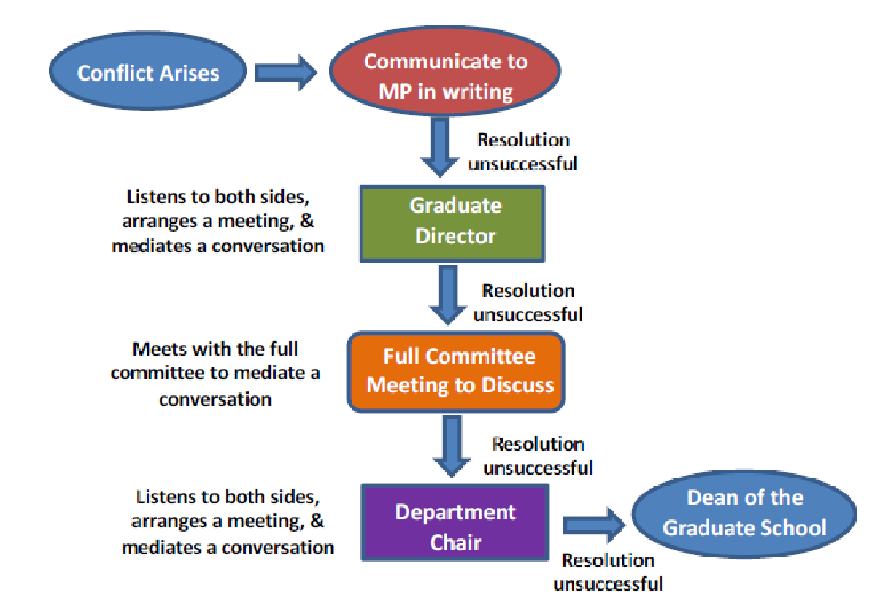

## Final Thoughts

Being part of this lab is about more than producing papers. It’s about learning to think deeply, work collaboratively, and grow into your own professional identity. I’m proud of the work we do, and excited to be on this tangled journey!